# Prediction of House Prices in Ames

### Analysis of response SalePrice

How well-behaved is the target?

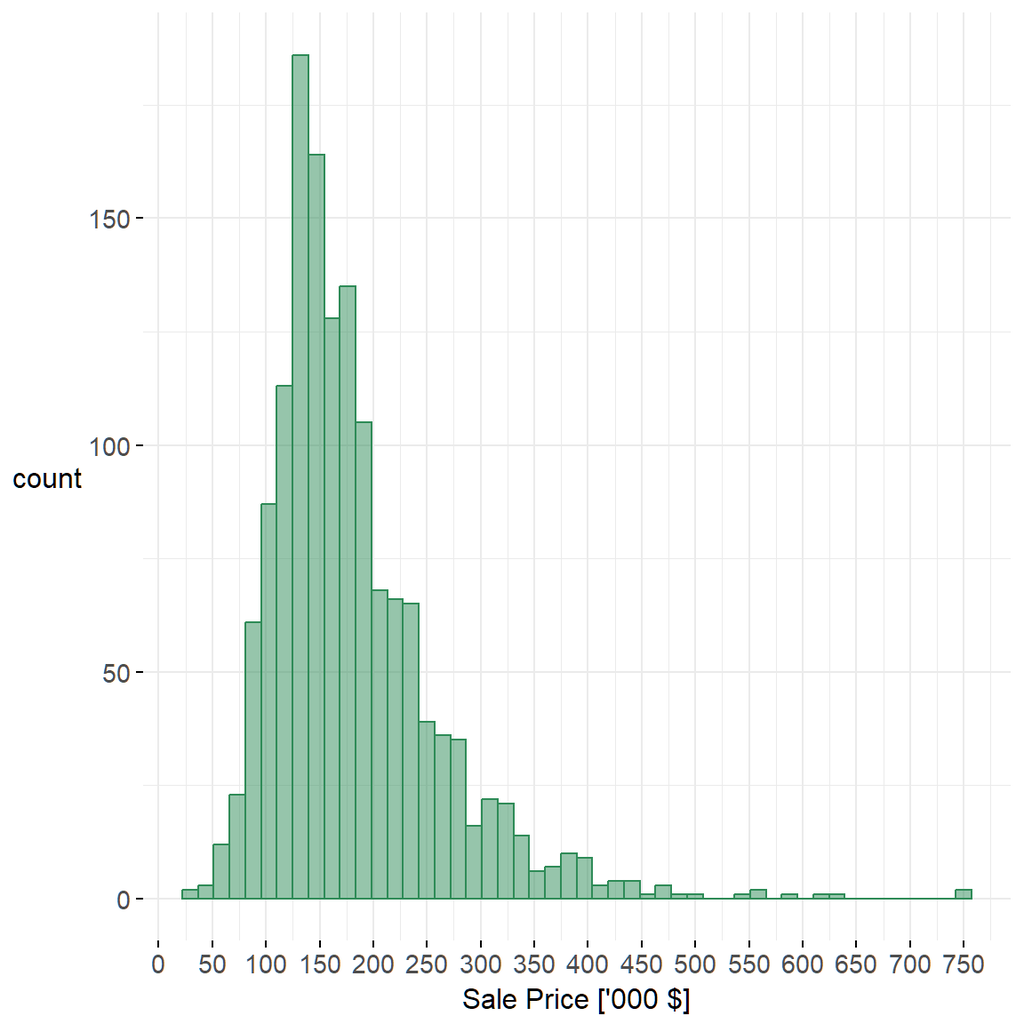

(a) Histogram

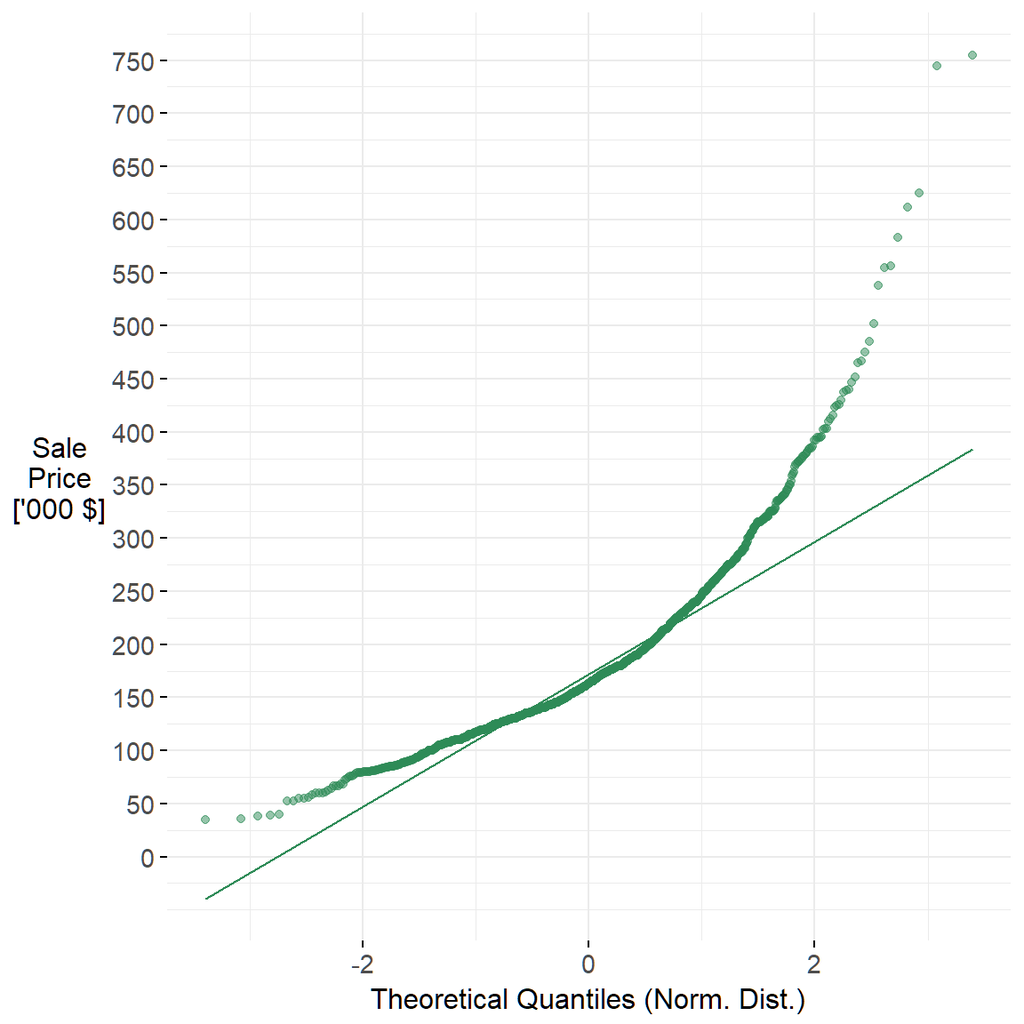

(b) Q-Q Plot

Figure 10: Analysis of the target variable. All the assumptions of OLS and linear regression are broken, as usual.

````markdown
```{r}
#| label: fig-Y
#| message: false
#| warning: false
#| column: body
#| fig-width: 6
#| fig-height: 6
#| fig-cap: "Analysis of the target variable. All the assumptions of OLS and linear regression are broken, as usual."
#| fig-subcap:
#|   - "Histogram"
#|   - "Q-Q Plot"
#| layout-ncol: 2

ames_all |>
  filter(dataset == "train") |>
  ggplot(aes(x = SalePrice/1000)) +
  geom_histogram(bins = 50, color = "seagreen", fill = "seagreen", alpha = 0.5) +
  scale_x_continuous(breaks = seq(0, 800, 50), labels = scales::comma) +
  labs(x = "Sale Price ['000 $]")

ames_all |>
  filter(dataset == "train") |>
  ggplot(aes(sample = SalePrice/1000)) +
  stat_qq(color = "seagreen", alpha = 0.5) +
  stat_qq_line(color = "seagreen") +
  scale_y_continuous(breaks = seq(0, 800, 50), labels = scales::comma) +
  labs(y = "Sale\nPrice\n['000 $]",
       x = "Theoretical Quantiles (Norm. Dist.)")
```
````

Clearly, the target variable is not well-behaved. It shows a log-normal distribution heavily skewed, to right of course. In order to achieve better predictions, a transformation might be needed.

#### Transformation of the response

For what I’ve seen, processes that have to do with *money*, e.g., sale prices, costs of products, salaries, they are most of the time **Log-normal**. Rarely there is something free, so you don’t have zeros or with negative value; think about the top 1% of reach people, or anything that becomes **premium** the higher the price. These are long and sparse right tails.

The logarithmic transformation works when there are few large values, like in this case, there are only a few expensive houses. The logarithm scale will shrink that right tail[^5], making the distribution more normal-like.

<sup>5</sup> Think of a **Logarithmic transformation** like pressing an **accordeon** only from your right arm.

Because we have powerful computers and libraries with written functions to perform variable transformations, I will use the Box-Cox transformation, which is a family of functions that includes the logarithmic one depending on the value of a parameter *lambda*. This parameter is automatically assessed.

*Family Box-Cox transformations*:

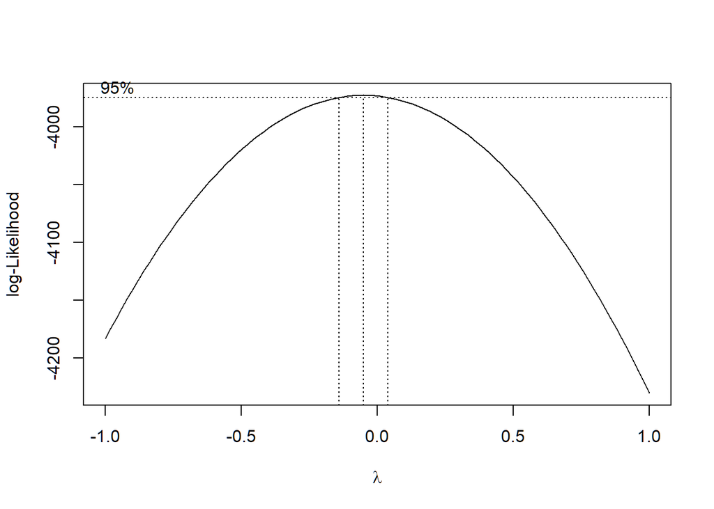

Figure 11: Best parameter lambda = -0.05050505. It is almost a pure logarithmic transformation.

````markdown
```{r}
#| label: fig-boxcox
#| fig-cap: "Best parameter lambda = -0.05050505. It is almost a pure logarithmic transformation."
#| column: margin
#| code-fold: false
#| warning: false
#| message: false

boxcox_trans <- MASS::boxcox(lm(SalePrice ~ 1,
                                data = subset(ames_all, dataset == "train")),
                             lambda = seq(-1, 1),
                             plotit = TRUE)

boxcox_lambda <- as.numeric(boxcox_trans$x[which.max(boxcox_trans$y)])

# New transformed response variable
ames_all <- ames_all |>
  mutate(SalePrice_bc = (SalePrice^boxcox_lambda - 1) / boxcox_lambda)
```
````

The new mutated `SalePrice` should be better behaved…

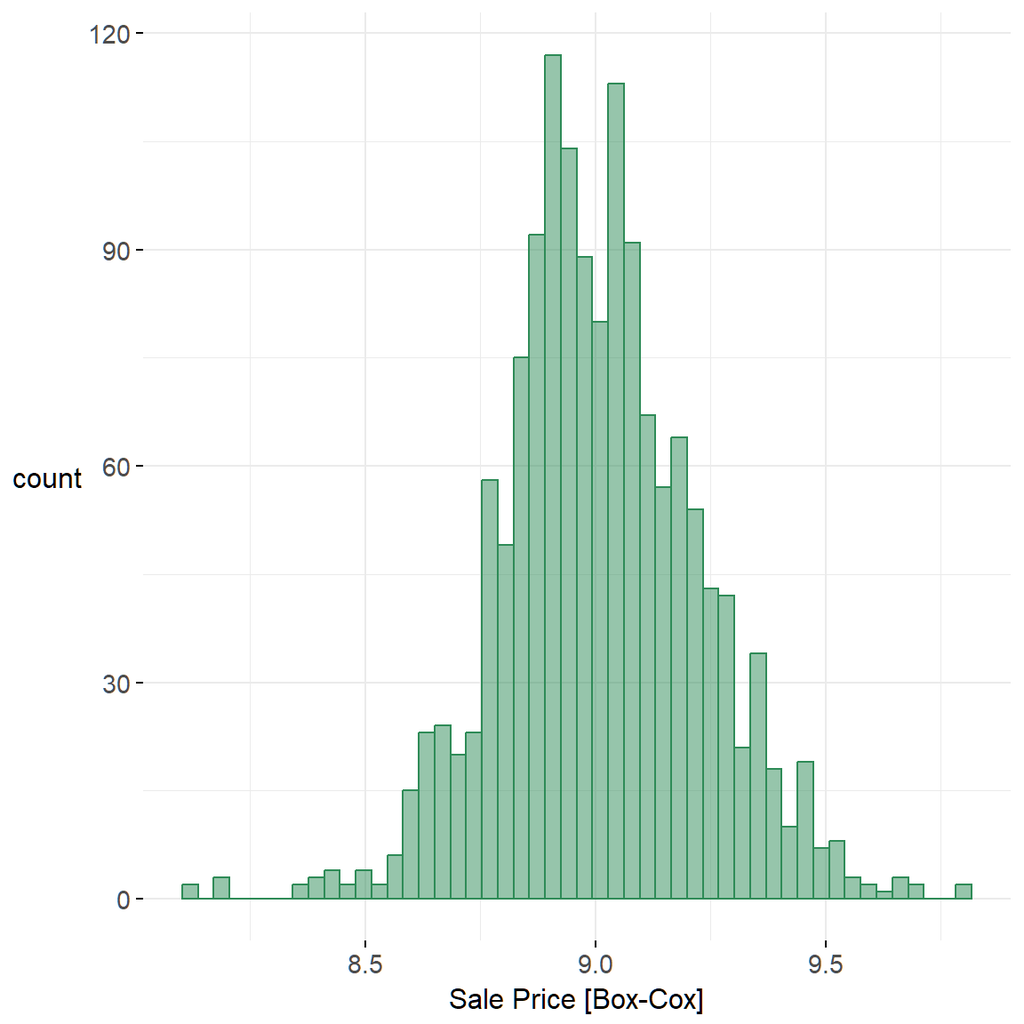

(a) Histogram

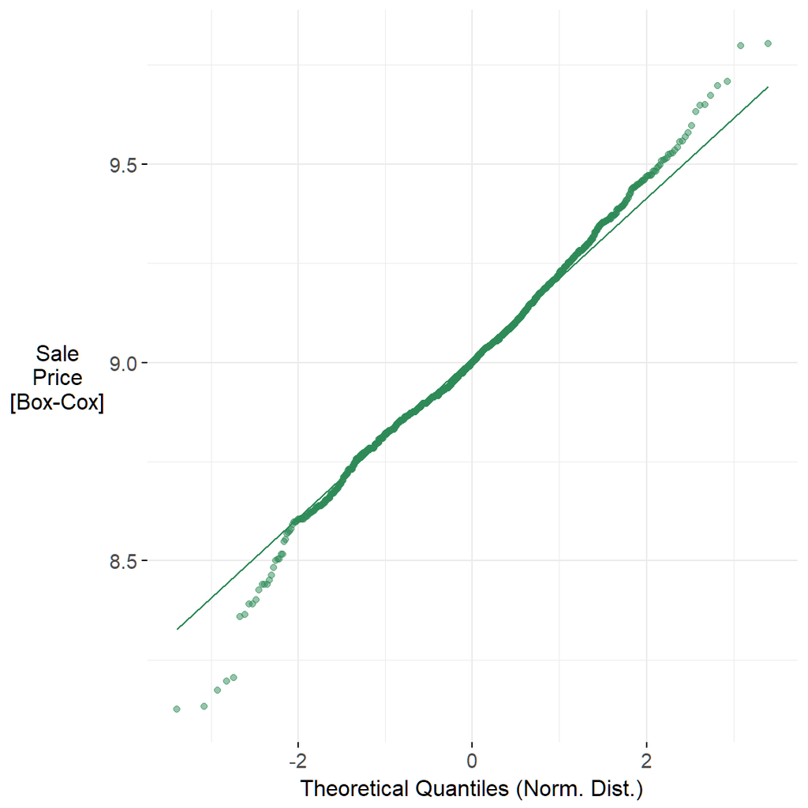

(b) Q-Q Plot

Figure 12: The transformed response shows a more bell-like shape.

````markdown
```{r}
#| label: fig-Y-trans
#| message: false
#| warning: false
#| column: body
#| fig-width: 6
#| fig-height: 6
#| fig-cap: "The transformed response shows a more bell-like shape."
#| fig-subcap:
#|   - "Histogram"
#|   - "Q-Q Plot"
#| layout-ncol: 2

ames_all |>
  filter(dataset == "train") |>
  ggplot(aes(x = SalePrice_bc)) +
  geom_histogram(bins = 50, color = "seagreen", fill = "seagreen", alpha = 0.5) +
  labs(x = "Sale Price [Box-Cox]")

ames_all |>
  filter(dataset == "train") |>
  ggplot(aes(sample = SalePrice_bc)) +
  stat_qq(color = "seagreen", alpha = 0.5) +
  stat_qq_line(color = "seagreen") +
  labs(y = "Sale\nPrice\n[Box-Cox]", x = "Theoretical Quantiles (Norm. Dist.)")
```
````

… and it is, indeed. Well, except for the tails, now the transformed values are more normal-like at the core.

**Do not include the transformation of the response as a step within the recipe.** It will cause an [error](https://github.com/tidymodels/recipes/issues/1033) with the *predict* function trying to locate `SalePrice` in the test dataset.

# PHASE 2: MODELLING

*“This is where the fun begins.”*

One of the motivations to develop this project is because I’m switching to the **Tidymodels** framework. Therefore, it’s time to load the library to train a simple reference model.

## Resampling for Test Error Estimation

This is a critical step for final model selection. Depending on the chosen resample technique to estimate the Goodness-of-Prediction or test error, in this case metrics like RMSE can be slightly optimistic or conservative. Take a look at the pristine explanation by (Zablotski 2022).

- **Simple validation set?** 1 train fold and 1 test fold: NO, it’s old and inaccurate.
- **v-folds Cross-Validation?** Analysis (training folds), Assessment (validation folds) and test: it’s *small data*, I can choose something even more powerful.
- **The Bootstrap?** YES.

By today’s standards this dataset is small, therefore I will choose Bootstraping to keep the chosen samples the same size as the training set. The probability of an observation of being sample at least once is 0.63, therefore the complementary training set (around 37%) will become the *assessment set*. Although performance metrics will be slightly conservative or pessimistic, I prefer it.

I will generate 1000 bootstrap-samples.

I will use 10-folds CV reapeated 10 times (100 splits) for the hyperparameter tuning of more complex algorithms. Once optimised, I’ll assess the test error again with the 1000 bootstraps, for the sake of comparison.

## Expending the data budget

Normally with v-fold CV I expend my data budget, but here doing resampling with replacement is kind of printing money… Here’s the code to generate the bootstraps and therefore split the data budget:

````markdown
```{r}
#| label: DataBudget
#| warning: false
#| fold: false

library(tidymodels)
tidymodels_prefer()
# conflicted::conflicts_prefer(scales::discard)

# Select the pre-processed training dataset
ames_train <-
  ames_all |>
  filter(dataset == "train")


# ---- v-folds Cross Validation ----
set.seed(1982)
ames_folds <- vfold_cv(ames_train, v = 10, repeats = 10, strata = SalePrice_bc) # v = 10 folds are default

set.seed(1982)
ames_folds_xgb <- vfold_cv(ames_train, v = 10, repeats = 1, strata = SalePrice_bc)

# ---- The Bootstrap ----
set.seed(1982)
ames_boots <- bootstraps(ames_train, times = 1000, strata = SalePrice_bc)
ames_boots
```
````

```
# A tibble: 1,000 × 2
   splits             id
   <list>             <chr>
 1 <split [1458/545]> Bootstrap0001
 2 <split [1458/530]> Bootstrap0002
 3 <split [1458/534]> Bootstrap0003
 4 <split [1458/535]> Bootstrap0004
 5 <split [1458/513]> Bootstrap0005
 6 <split [1458/534]> Bootstrap0006
 7 <split [1458/519]> Bootstrap0007
 8 <split [1458/532]> Bootstrap0008
 9 <split [1458/529]> Bootstrap0009
10 <split [1458/555]> Bootstrap0010
# ℹ 990 more rows
```

For the sake of RMSE metric comparison I will always scale numeric predictors and use the Box-Cox transformed response `SalePrice_bc`, this given the improvement shown in Figure 12.

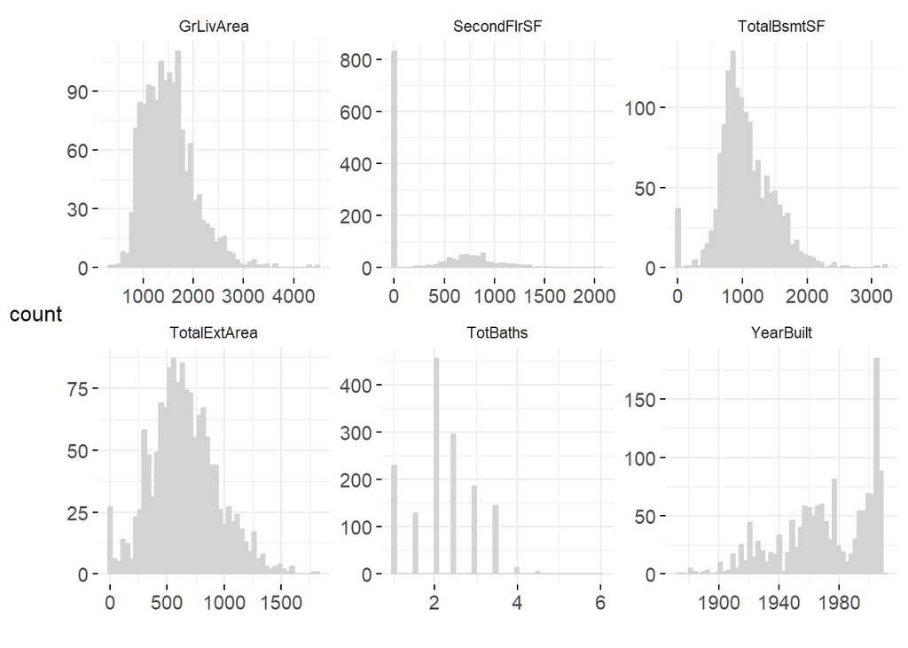

````markdown
```{r}
#| label: fig-skewed-feats
#| fig-cap: "Sample of skewed numerical predictors that contain zero as value."

ames_train |>
  select(c(GrLivArea, TotBaths, TotalExtArea, TotalBsmtSF, YearBuilt, SecondFlrSF)) |>
  pivot_longer(GrLivArea:SecondFlrSF) |>
  ggplot(aes(x = value)) +
  geom_histogram(bins = 50, color = "lightgrey", fill = "lightgrey") +
  labs(x = "") +
  facet_wrap(~name, scales = "free")
```
````

Given the sensitivity to tails and outliers of linear models, remember Figure 4 (a), it will be convenient to try to normalise the distribution of these predictors. However, Box-Cox transformations work only for positive data. The alternative will be the more general **Yeo-Johnson transformation**, which works for both, positive and negative values.

Note that `SalePrice_bc` is the transformed outcome. Click [here](https://www.tmwr.org/recipes.html#skip-equals-true) for more info.

My reference is the **linear GAM with Splines**, showing a mean RMSE = 0.0812. The result was transformed in the pipeline, therefore no units are displayed.

I got slightly better results using dummy encoded factors. Moreover, applying the Yeo-Johnson transformation to numeric Feats. helped too! They were skewed, see Figure 13.

## Elastic-Net Regression

Having high multicollinearity it’s reasonable to think of some sort of penalisation or shrinkage method. Hence, I’ll go with a Generalised Linear Model, [GLM](https://glmnet.stanford.edu/articles/glmnet.html). In this manner I can have a first look at feature importance.

I’ll choose Elastic Net regression, combining the best of Lasso and Ridge. I must remember to myself that *predictors* must be scaled! I don’t want to over-penalised non-scaled variables using shrinkage methods.

### Elastic-Net Spec & Tuning

````markdown
```{r}
#| label: Elastic-net-setup
#| eval: false

library(embed)

# Elastic Net
glmnet_base_rec <-
  recipe(SalePrice_bc ~ ., data = ames_train) |>
  update_role(Id, new_role = "Id variable") |>
  update_role(SalePrice, new_role = "original outcome") |>
  update_role(dataset, new_role = "splitting variable") |>
  step_lencode_glm(MSSubClass, outcome = vars(SalePrice_bc)) |>
  step_dummy(all_nominal_predictors()) |>
  step_YeoJohnson(all_numeric_predictors()) |>
  step_zv(all_predictors()) |>
  step_normalize(all_numeric_predictors())

# glmnet_base_rec |> prep() |> bake(new_data = NULL)

# library(usemodels)  # CheatSheets

# Model: Elastic Net -------------
glmnet_spec <-
  linear_reg(penalty = tune(), mixture = tune()) |>
  set_engine("glmnet") |>
  set_mode("regression")
  # translate()

glmnet_wf <-
  workflow() |>
  add_recipe(glmnet_base_rec) |>
  add_model(glmnet_spec)

# penalty = lambda; mixture = alpha (0 - Ridge, 1- Lasso)

# penalty_ <- 10^seq(-4, -1, length.out = 20)
# mixture_ = c(0.05, 0.2, 0.4, 0.6, 0.8, 1)
penalty_ <- 10^seq(-3, -2, length.out = 40)
mixture_ <- c(0, 0.05, 0.1, 0.15, 0.2, 0.25, 0.3, 0.35, 0.4, 0.45, 0.5, 0.55, 0.6)

glmnet_grid <- tidyr::crossing(penalty = penalty_,
                               mixture = mixture_)

# Tune with Folds

tic("opt-ElasticNet")
set.seed(1982)
doParallel::registerDoParallel()

glmnet_tune <- tune_grid(glmnet_wf,
                         resamples = ames_folds,  # CV is faster!
                         grid = glmnet_grid)

toc()

# Explore Results
show_best(glmnet_tune, metric = "rmse")

# Set best parameters
final_glmnet <- glmnet_wf |> finalize_workflow(select_best(glmnet_tune, metric = "rmse"))
final_glmnet

write_rds(final_glmnet, file = "./models/final_models/final_glmnet.rds")
```
````

### Elastic-Net Test Error Assessment

````markdown
```{r}
#| label: final_glmnet_assessment
#| eval: false

tic("elastic-net fit bootstaps")
glmnet_boot_fit <-
  final_glmnet |>
  fit_resamples(resamples = ames_boots)

glmnet_boot_fit |>
  collect_metrics(summarize = TRUE)
toc()
```
````

````markdown
```{r}
#| label: load_elnet_model

final_glmnet <- read_rds(file = "./models/final_models/final_glmnet.rds")
final_glmnet
```
````

```
══ Workflow ════════════════════════════════════════════════════════════════════
Preprocessor: Recipe
Model: linear_reg()

── Preprocessor ────────────────────────────────────────────────────────────────
5 Recipe Steps

• step_lencode_glm()
• step_dummy()
• step_YeoJohnson()
• step_zv()
• step_normalize()

── Model ───────────────────────────────────────────────────────────────────────
Linear Regression Model Specification (regression)

Main Arguments:
  penalty = 0.00888623816274341
  mixture = 0.15

Computational engine: glmnet
```

New fit with new feature engineering, mean RMSE = 0.0636 (1000 Bootstraps). **Kaggle’s Top 15%**.

#### Elastic-Net Submission

````markdown
```{r}
#| label: Elastic-Net_submission
#| eval: false

# Get best model and fit with whole training set
fit_glm_elnet <-
  final_glmnet |>
  fit(ames_train)

# Predicting on the test set
ames_test <-
  ames_all |>
  # select(-SalePrice) |>
  filter(dataset == "test")

res_elasticnet <-
  predict(fit_glm_elnet, ames_test) |>
  mutate(SalePrice_pred = inv_boxcox(.pred, boxcox_lambda))  # orignal values in USD

# .csv for submission
sub_elasticnet <- data.frame(Id = ames_test$Id, SalePrice = res_elasticnet$SalePrice_pred)
write.csv(sub_elasticnet, "./data/submissions/jthom_sub_5_elasticnet.csv", quote = FALSE, row.names = FALSE)
```
````

### XGBoost Regression

Because of the multicollinearity, XGBoost is one of the best candidates for this project.

#### XGBoost Spec & Tuning

````markdown
```{r}
#| label: XGB-set-tune
#| eval: false

library(xgboost)

xgboost_rec <-
  recipe(formula = SalePrice_bc ~ ., data = ames_train) |>
  update_role(Id, new_role = "Id variable") |>
  update_role(SalePrice, new_role = "original outcome") |>
  update_role(dataset, new_role = "splitting variable") |>
  step_lencode_glm(MSSubClass, outcome = vars(SalePrice_bc)) |>
  step_dummy(all_nominal_predictors()) |>
  step_YeoJohnson(all_numeric_predictors()) |>
  step_zv(all_predictors()) |>
  step_normalize(all_numeric_predictors())

xgboost_spec <-
  boost_tree(trees = tune(),
             min_n = tune(),
             tree_depth = tune(),
             learn_rate = tune(),
             loss_reduction = tune(),
             sample_size = tune()) |>
  set_mode("regression") |>
  set_engine("xgboost", validation = 0.2) # 20% from train split of each resample

xgboost_wf <-
  workflow() |>
  add_recipe(xgboost_rec) |>
  add_model(xgboost_spec)

# tic("opt_xgboost")

# set.seed(1982)
# doParallel::registerDoParallel()

# xgboost_tune <-
#   tune_grid(xgboost_wf,
#             resamples = ames_folds,
#             grid = 60)

# toc()

# Explore Results
# show_best(xgboost_tune, metric = "rmse")

# Best Selection
#   trees = 1300
#   min_n = 3
#   tree_depth = 13
#   learn_rate = 0.0087033422152885
#   loss_reduction = 3.4747461708994e-08
#   sample_size = 0.175630365774268

# Set best parameters

# final_xgboost <- xgboost_wf |>
#   finalize_workflow(select_best(xgboost_tune, metric = "rmse"))

final_xgboost <- read_rds(file = "./models/final_models/final_xgboost.rds")
final_xgboost

# write_rds(final_xgboost, file = "./models/final_models/final_xgboost.rds")

# Assessment of test error
```
````

A total of **2.8 hours** for the search of 6 hyperparameters in 60 randomly-generated grids using 100 splits (10-CV folds, repeated 10 times). See the commented code above with the best ones selected (RMSE).

````markdown
```{r}
#| label: final_xgboost_assessment
#| eval: false

# tic("test_xgboost")

xgboost_boot_fit <-
  final_xgboost |>
  fit_resamples(resamples = ames_boots)

xgboost_boot_fit |>
  collect_metrics(summarize = TRUE)

toc()
```
````

XGBoost fit: Test Error estimation mean (of 1000 Bootstraps) RMSE = 0.0666.

#### XGBoost Submission

Results **not submitted** given the slightly worse performance than Elasti-Net (above). However, results will be used to build an ensemble (stacking).

````markdown
```{r}
#| label: XGB_submission
#| eval: false

# Get best model and fit with whole training set
fit_xgboost <-
  final_xgboost |>
  fit(ames_train)

# Predicting on the test set
ames_test <-
  ames_all |>
  filter(dataset == "test")

res_xgboost <-
  predict(fit_xgboost, ames_test) |>
  mutate(SalePrice_pred = inv_boxcox(.pred, boxcox_lambda))  # orignal values in USD

# .csv for submission
sub_xgboost <- data.frame(Id = ames_test$Id, SalePrice = res_xgboost$SalePrice_pred)
write.csv(sub_xgboost, "./data/submissions/jthom_sub_4_xgboost.csv", quote = FALSE, row.names = FALSE)
```
````

## Models Stacking

### Mean of Predictions

The simplest ensemble, often very effective when the nature of the models are different like in this case! The Elastic-Net regression had a better RMSE than the XGBoost, therefore I can give more weight to it:

````markdown
```{r}
#| label: stack_1
#| eval: false
#| code-fold: false

# (elastic_net_pred + elastic_net_pred + xgboost_pred)/3

avg_elnet_xgb <- ((2*res_elasticnet$SalePrice_pred) + res_xgboost$SalePrice_pred)/3

sub_stack_elnet_xgb <- data.frame(Id = ames_test$Id, SalePrice = avg_elnet_xgb)

write.csv(sub_stack_elnet_xgb, "./data/submissions/jthom_sub_5_stack_elnet_xgb.csv",
          quote = FALSE,
          row.names = FALSE)
```
````

This was a **top 11%** Kaggle submission! Best so far…

*…to be continue…*

J. Thomas

## References

Anna Montoya, DataCanary. 2016. “House Prices - Advanced Regression Techniques.” Kaggle. https://kaggle.com/competitions/house-prices-advanced-regression-techniques.

R Core Team. 2023. *R: A Language and Environment for Statistical Computing*. Vienna, Austria: R Foundation for Statistical Computing. https://www.R-project.org/.

Zablotski, Yury. 2022. *Effective Resampling for Machine Learning in Tidymodels rsample r Package Reviews*. https://www.youtube.com/watch?v=GtAX7Y2F4aY.